# Simulacro para practicar con datos Capturas

Maria del Carmen Martínez Caro

2024

```r
# Crear el dataframe
capturas_peces <- data.frame(
  Fecha = as.Date(character(), format = "%d/%m/%Y"),
  Zona = character(),
  Pais = character(),
  Especie = character(),
  Arte_de_pesca = character(),
  Peso = numeric()
)

# Añadimos 2000 registros aleatorios
set.seed(123) # Para reproducibilidad de los resultados
for (i in 1:6000) {
  capturas_peces[i, "Fecha"] <- as.Date(sample(seq(as.Date('2020/01/01'), as.Date('2023/12/31'), by="day"), 1))
  capturas_peces[i, "Zona"] <- sample(c("Atlántico Norte", "Mediterráneo", "Golfo de México", "Mar del Norte", "Mar del Este", "Océano Índico", "Pacífico Sur", "Atlántico Sur"), 1)
  capturas_peces[i, "Pais"] <- sample(c("España", "Italia", "México", "Países Bajos", "Rusia", "India", "Chile", "Argentina", "Estados Unidos", "Noruega", "Japón"), 1)
  capturas_peces[i, "Especie"] <- sample(c("Merluza", "Lubina", "Bacalao", "Salmón", "Atún", "Dorada"), 1)
  capturas_peces[i, "Arte_de_pesca"] <- sample(c("Arrastre", "Red de enmalle", "Línea de mano", "Red de arrastre", "Red de cerco"), 1)
  capturas_peces[i, "Peso"] <- round(runif(1, min = 1, max = 20), 1)
}

# Muestra las primeras filas del dataframe
head(capturas_peces)
```

```
##        Fecha            Zona    Pais Especie   Arte_de_pesca Peso
## 1 2021-02-18    Pacífico Sur  México  Dorada   Línea de mano  1.9
## 2 2023-02-15 Golfo de México   Rusia  Salmón        Arrastre  3.0
## 3 2021-12-09 Golfo de México   Japón Merluza Red de arrastre 13.2
## 4 2023-10-10   Atlántico Sur Noruega  Lubina        Arrastre 18.1
## 5 2020-07-29   Mar del Norte  España Bacalao    Red de cerco  5.4
## 6 2023-03-12   Atlántico Sur Noruega    Atún        Arrastre  5.4
```

```r
# Convierte las variables a los tipos de datos adecuados
capturas_peces$Zona <- as.factor(capturas_peces$Zona)
capturas_peces$Pais <- as.factor(capturas_peces$Pais)
capturas_peces$Especie <- as.factor(capturas_peces$Especie)
capturas_peces$Arte_de_pesca <- as.factor(capturas_peces$Arte_de_pesca)
```

```r
# Extraer y guardar los datos que son de Merluza
merluza_data <- subset(capturas_peces, Especie == "Merluza")

# Otra forma de hacerlo
merluza_data <- capturas_peces[capturas_peces$Especie == "Merluza", ]

head(merluza_data)
```

```
##         Fecha            Zona         Pais Especie   Arte_de_pesca Peso
## 3  2021-12-09 Golfo de México        Japón Merluza Red de arrastre 13.2
## 9  2021-08-10    Pacífico Sur       Italia Merluza        Arrastre 16.1
## 10 2020-06-01   Océano Índico        Rusia Merluza  Red de enmalle  8.2
## 12 2021-08-20   Océano Índico        Chile Merluza  Red de enmalle  7.5
## 23 2023-06-15   Mar del Norte       México Merluza  Red de enmalle 11.7
## 25 2021-11-10   Océano Índico Países Bajos Merluza   Línea de mano  4.2
```

```r
# Calcula el peso total de cada especie
peso_total_especie <- aggregate(Peso ~ Especie, data = capturas_peces, FUN = sum)

# Renombra la columna resultante
names(peso_total_especie)[2] <- "Peso_total"

# Muestra el peso total de cada especie
print(peso_total_especie)
```

```
##   Especie Peso_total
## 1    Atún    11015.4
## 2 Bacalao    10356.1
## 3  Dorada    10004.4
## 4  Lubina    10325.4
## 5 Merluza    10895.5
## 6  Salmón    10117.9
```

```r
# Carga el paquete lubridate
library(lubridate)
# Extrae la información del año y el mes de la columna Fecha
capturas_peces$Anyo <- year(capturas_peces$Fecha)
capturas_peces$Mes <- month(capturas_peces$Fecha, label = TRUE)
capturas_peces$Anyo <- as.factor(capturas_peces$Anyo)

# Muestra las primeras filas del dataframe con las nuevas columnas
head(capturas_peces)
```

```
##        Fecha            Zona    Pais Especie   Arte_de_pesca Peso Anyo Mes
## 1 2021-02-18    Pacífico Sur  México  Dorada   Línea de mano  1.9 2021 feb
## 2 2023-02-15 Golfo de México   Rusia  Salmón        Arrastre  3.0 2023 feb
## 3 2021-12-09 Golfo de México   Japón Merluza Red de arrastre 13.2 2021 dic
## 4 2023-10-10   Atlántico Sur Noruega  Lubina        Arrastre 18.1 2023 oct
## 5 2020-07-29   Mar del Norte  España Bacalao    Red de cerco  5.4 2020 jul
## 6 2023-03-12   Atlántico Sur Noruega    Atún        Arrastre  5.4 2023 mar
```

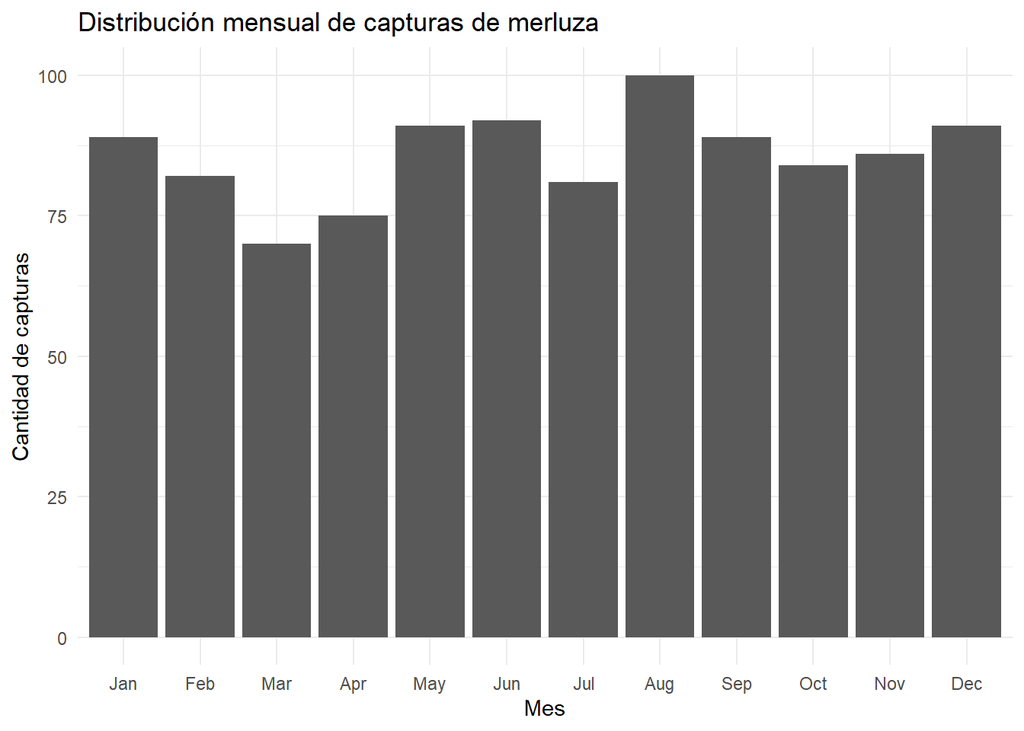

```r
library(ggplot2)
# Calcula el mes a partir de la columna Fecha
merluza_data$Mes <- month(merluza_data$Fecha, label = TRUE)

# Crea el gráfico de barras
ggplot(merluza_data, aes(x = Mes)) +
  geom_bar() +
  labs(title = "Distribución mensual de capturas de merluza",
       x = "Mes",
       y = "Cantidad de capturas") +
  scale_x_discrete(labels = month.abb) +  # Usa nombres de meses abreviados
  theme_minimal()
```

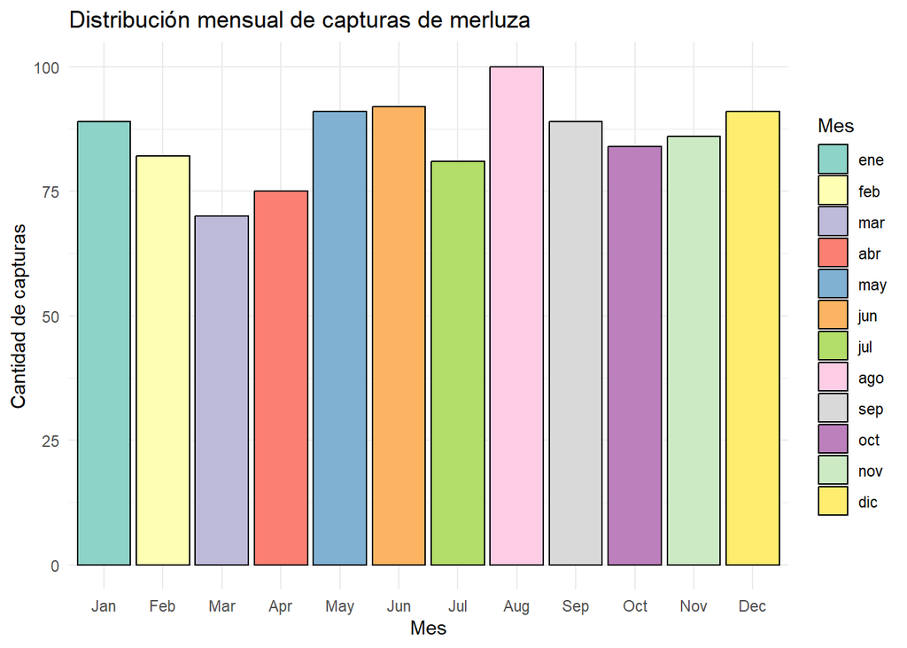

```r
# Crea el gráfico de barras con colores personalizados
ggplot(merluza_data, aes(x = Mes, fill = Mes)) +
  geom_bar(color = "black") +  # Añade un borde negro a las barras
  labs(title = "Distribución mensual de capturas de merluza",
       x = "Mes",
       y = "Cantidad de capturas") +
  scale_x_discrete(labels = month.abb) +  # Usa nombres de meses abreviados
  scale_fill_brewer(palette = "Set3") +  # Elige un esquema de color
  theme_minimal()
```

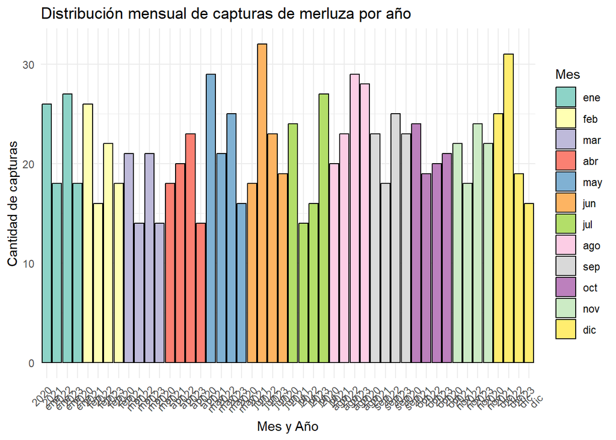

```r
# Teniendo en cuenta el año también
# Calcula el año a partir de la columna Fecha
merluza_data$Anyo <- year(merluza_data$Fecha)

# Peso de la Merluza estando los meses-años en el eje X y los meses en la leyenda
ggplot(merluza_data, aes(x = interaction(Anyo, Mes), fill = Mes)) +
  geom_bar(color = "black") +  # Añade un borde negro a las barras
  labs(title = "Distribución mensual de capturas de merluza por año",
       x = "Mes y Año",
       y = "Cantidad de capturas") +
  scale_x_discrete(labels = function(x) gsub("\\.", "\n", x)) +  # Ajusta la visualización de los niveles de interacción
  scale_fill_brewer(palette = "Set3") +  # Elige un esquema de color
  theme_minimal() +
  theme(axis.text.x = element_text(angle = 45, hjust = 1))  # Ajusta la inclinación del texto en el eje x
```

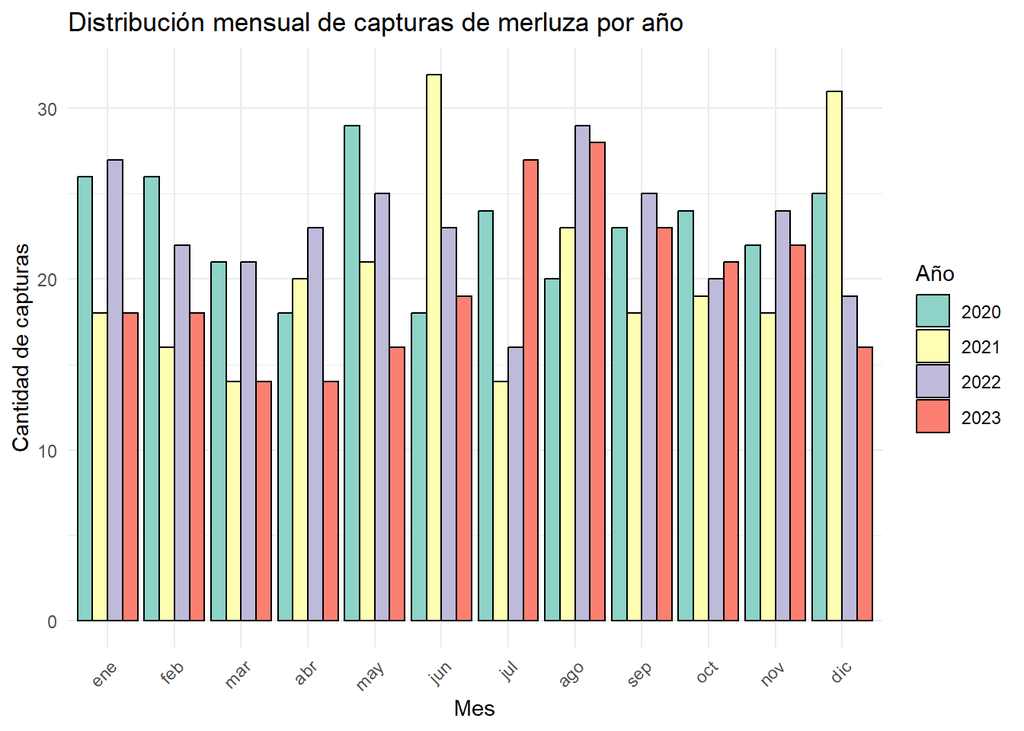

```r
# Peso de la Merluza estando los meses en el eje X y los años en la leyenda
ggplot(merluza_data, aes(x = Mes, fill = factor(Anyo))) +
  geom_bar(position = "dodge", color = "black") +  # Añade un borde negro a las barras
  labs(title = "Distribución mensual de capturas de merluza por año",
       x = "Mes",
       y = "Cantidad de capturas",
       fill = "Año") +
  scale_fill_brewer(palette = "Set3") +  # Elige un esquema de color
  theme_minimal() +
  theme(axis.text.x = element_text(angle = 45, hjust = 1))  # Ajusta la inclinación del texto en el eje x
```

```r
library(dplyr)
```

```r
# Data frame con la columna "Zona"
df <- data.frame(Zona = c("27.8.a Celtic Sea Sur", "27.8.d.2 Golfo de Vizcaya", "27.8.b Suroeste de Irlanda"))

# Dividir la columna "Zona"
split_zona <- strsplit(df$Zona, split = " ")
split_zona
```

```
## [[1]]
## [1] "27.8.a" "Celtic" "Sea"    "Sur"
##
## [[2]]
## [1] "27.8.d.2" "Golfo"    "de"       "Vizcaya"
##
## [[3]]
## [1] "27.8.b"   "Suroeste" "de"       "Irlanda"
```

```r
# Crear columna "ZonaPrincipal" con solo el primer número del código
df$ZonaPrincipal <- sapply(split_zona, function(x) substr(x[1], 1, 2))  # Primer número del código (27)

# Columna "Subzona" con el resto del código
df$Subzona <- sapply(split_zona, "[[", 2)  # Resto del código (subzona)
df$NombreZona <- sapply(split_zona, "[[", 3)  # Nombre completo de la zona

df
```

```
##                         Zona ZonaPrincipal  Subzona NombreZona
## 1      27.8.a Celtic Sea Sur            27   Celtic        Sea
## 2  27.8.d.2 Golfo de Vizcaya            27    Golfo         de
## 3 27.8.b Suroeste de Irlanda            27 Suroeste         de
```

```r
######################################################

library(stringr)
```

```r
# Data
df <- data.frame(Zona = c("27.8.a Celtic Sea Sur", "27.8.d.2 Golfo de Vizcaya", "27.8.b Suroeste de Irlanda"))

# Separar la variable Zona en tres columnas
df <- df %>%
    mutate(Zona_Principal = str_extract(Zona, "\\d+"),
           Subzona = str_extract(Zona, "\\..*?\\s"),
           Nombre_Zona = str_replace(Zona, "\\d+\\..*?\\s", ""))

print(df)
```

```
##                         Zona Zona_Principal Subzona         Nombre_Zona
## 1      27.8.a Celtic Sea Sur             27   .8.a       Celtic Sea Sur
## 2  27.8.d.2 Golfo de Vizcaya             27 .8.d.2     Golfo de Vizcaya
## 3 27.8.b Suroeste de Irlanda             27   .8.b  Suroeste de Irlanda
```

## Otras ideas

### Analisis de frecuencia

Para entender la distribución de cada factor, ver la frecuencia de campturas en cada mes o en cáda área FAO por ejemplo

```r
library(dplyr)

# Crear una tabla de frecuencia para los meses
tabla_meses <- table(merluza_data$Mes)

# Mostrar la tabla de frecuencia
print(tabla_meses)
```

```
##
## ene feb mar abr may jun jul ago sep oct nov dic
##  89  82  70  75  91  92  81 100  89  84  86  91
```

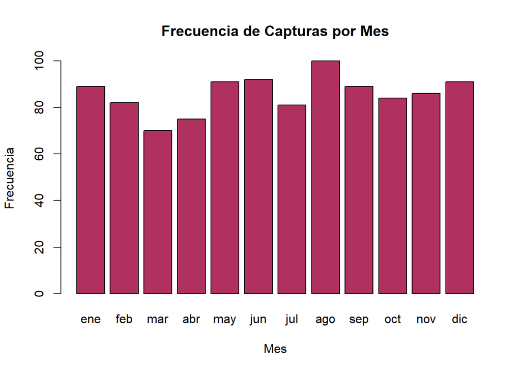

```r
# Crear un gráfico de barras para visualizar la frecuencia por mes
barplot(tabla_meses, main = "Frecuencia de Capturas por Mes", xlab = "Mes", ylab = "Frecuencia", col = "maroon")
```

### Tablas de contingencia

Las tablas de contingencia permiten examinar las relaciones entre dos variables categóricas. Para por ejemplo visualizar cómo varía la captura de x especie en diferenes meses o áreas FAO; es decir para ver la distribución de las capturas de merluza en distintos meses.

```r
library(dplyr)

# Crear la tabla de contingencia
tabla_contingencia <- table(merluza_data$Mes, merluza_data$Anyo)

# Mostrar la tabla de contingencia
print(tabla_contingencia)
```

```
##
##       2020 2021 2022 2023
##   ene   26   18   27   18
##   feb   26   16   22   18
##   mar   21   14   21   14
##   abr   18   20   23   14
##   may   29   21   25   16
##   jun   18   32   23   19
##   jul   24   14   16   27
##   ago   20   23   29   28
##   sep   23   18   25   23
##   oct   24   19   20   21
##   nov   22   18   24   22
##   dic   25   31   19   16
```

```r
# Los numéros en la tabla representan la cantidad de capturas de merluza para cada combinación de mes y año. Por ejemplo, en enero de 2020 hubo 26 capturas de merluza


# Calcular las proporciones marginales por fila y columna
proporciones_filas <- prop.table(tabla_contingencia, margin = 1)  # Proporciones marginales por fila
proporciones_columnas <- prop.table(tabla_contingencia, margin = 2)  # Proporciones marginales por columna

# Mostrar las proporciones marginales por fila y columna
print(proporciones_filas)
```

```
##
##            2020      2021      2022      2023
##   ene 0.2921348 0.2022472 0.3033708 0.2022472
##   feb 0.3170732 0.1951220 0.2682927 0.2195122
##   mar 0.3000000 0.2000000 0.3000000 0.2000000
##   abr 0.2400000 0.2666667 0.3066667 0.1866667
##   may 0.3186813 0.2307692 0.2747253 0.1758242
##   jun 0.1956522 0.3478261 0.2500000 0.2065217
##   jul 0.2962963 0.1728395 0.1975309 0.3333333
##   ago 0.2000000 0.2300000 0.2900000 0.2800000
##   sep 0.2584270 0.2022472 0.2808989 0.2584270
##   oct 0.2857143 0.2261905 0.2380952 0.2500000
##   nov 0.2558140 0.2093023 0.2790698 0.2558140
##   dic 0.2747253 0.3406593 0.2087912 0.1758242
```

```r
print(proporciones_columnas)
```

```
##
##             2020       2021       2022       2023
##   ene 0.09420290 0.07377049 0.09854015 0.07627119
##   feb 0.09420290 0.06557377 0.08029197 0.07627119
##   mar 0.07608696 0.05737705 0.07664234 0.05932203
##   abr 0.06521739 0.08196721 0.08394161 0.05932203
##   may 0.10507246 0.08606557 0.09124088 0.06779661
##   jun 0.06521739 0.13114754 0.08394161 0.08050847
##   jul 0.08695652 0.05737705 0.05839416 0.11440678
##   ago 0.07246377 0.09426230 0.10583942 0.11864407
##   sep 0.08333333 0.07377049 0.09124088 0.09745763
##   oct 0.08695652 0.07786885 0.07299270 0.08898305
##   nov 0.07971014 0.07377049 0.08759124 0.09322034
##   dic 0.09057971 0.12704918 0.06934307 0.06779661
```

Las proporciones marginales por fila indican la proporción de capturas de merluza en cada mes en comparación con el total de capturas de ese mes a lo largo de todos los años. Por ejemplo, enero de 2020 representa el 29.21% del total de capturas en enero a lo largo de todos los años.

Estas proporciones marginales te dan una idea de la distribución relativa de las capturas de merluza a lo largo de los meses y los años. Por ejemplo, puedes observar si hay meses o años específicos con una mayor proporción de capturas en comparación con otros.

### Gráficos de barras

Ya hemos hecho, pero sería por ejemplo para mostrar la cantidad de capturas en cada mes o en cada área FAO.

## Exploración Temporal

### Series temmporales

Gráficos de series temporales para visualizar cómo varían las capturas de merluza a lo largo del tiempo

```r
library(readr) # para leer los datos
library(ggplot2) # graficar
library(forecast)
library(grid)
library(gridExtra)
library(stats) #libreria para usar función ts y convertir a clase serie temporal
library(tidyverse) #trasformar los datos a serie temporal
library(cowplot) # para la combinación de grágicos FAC
library(urca)

#Primero nos tenemos que asegurar de que las fechas del dataframe están ordenadas

# Ordenar el dataframe en función de Fecha
merluza_data <- merluza_data %>%
  arrange(Fecha)

# Encontrar la fecha mínima
fecha_minima <- min(merluza_data$Fecha); max(merluza_data$Fecha)
```

```
## [1] "2023-12-31"
```

```r
# Obtener el año y mes de la fecha mínima
anio_minimo <- as.numeric(format(fecha_minima, "%Y"))
mes_minimo <- as.numeric(format(fecha_minima, "%m"))
anio_minimo; mes_minimo
```

```
## [1] 2020
```

```
## [1] 1
```

```r
# Agrupar los datos por Mes y Anyo
datos_validos <- merluza_data %>%
  group_by(Mes, Anyo) %>%
  summarise(n = n())
```

[output not shown]

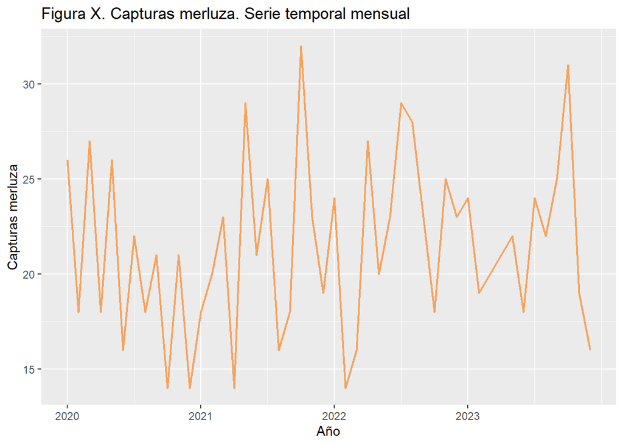

```r
# Crear una serie de tiempo
serie <- ts(datos_validos$n, start = c(anio_minimo, mes_minimo), freq = 12)

autoplot(serie,
         xlab = "Año",
         ylab = "Capturas merluza",
         main = "Figura X. Capturas merluza. Serie temporal mensual",
         col = "#f4a460", size = 0.8) +
    scale_x_continuous(breaks = seq(2020, 2023, 1))
```

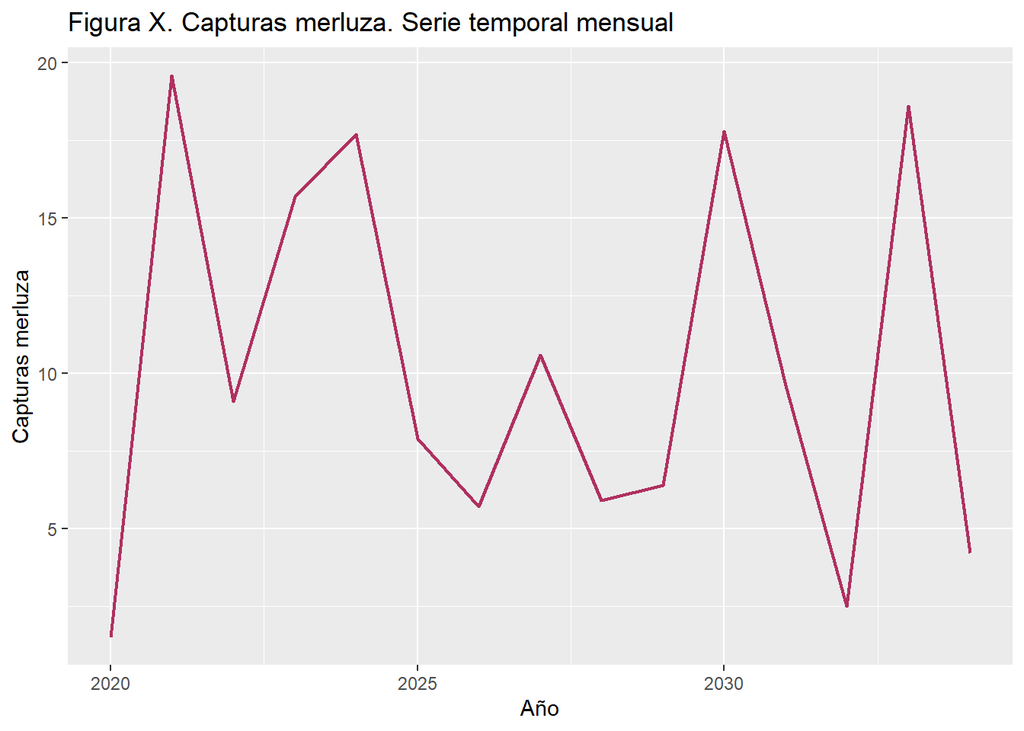

```r
# Crear la serie temporal
serie_temporal <- ts(merluza_data$Peso, frequency = 1, start = c(year(min(merluza_data$Fecha)), month(min(merluza_data$Fecha))), end = c(year(max(merluza_data$Fecha)), month(max(merluza_data$Fecha))))

autoplot(serie_temporal,
         xlab = "Año",
         ylab = "Capturas merluza",
         main = "Figura X. Capturas merluza. Serie temporal mensual",
         col = "maroon", size = 0.8)
```

### Análisis estacional Examinar si hay patrones estacionales en las capturas de merluza utilizando métodos como la descomposición estacional

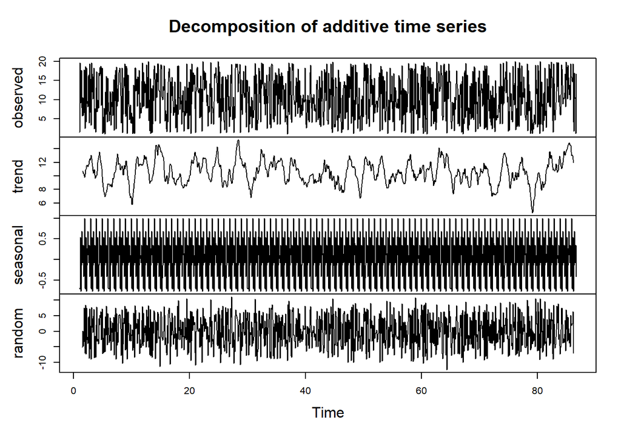

```r
library(forecast)

# Convertir los datos a una serie temporal
serie_temporal <- ts(merluza_data$Peso, frequency = 12)

# Realizar descomposición estacional
descomposicion <- decompose(serie_temporal)

# Plotear la descomposición estacional
plot(descomposicion)
```

### Tendencias a largo plazo

Usando técnicas de análisis de series temporales

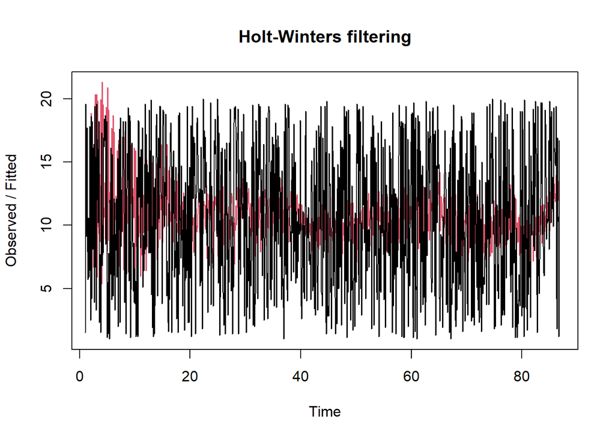

```r
# Aplicar suavizado exponencial
suavizado <- HoltWinters(serie_temporal)

# Plotear la serie original y el suavizado exponencial
plot(suavizado)
```

(todo esto en vez de hacerlo con el peso, habría que hacerlo con las capturas en sí)

## Exploración Espacial

### Mapas de calor

Mapa de calor que muestre la cantidad de capturas en cada mes y en cada área FAO.

```r
library(ggplot2)

# Crear un mapa de calor de las capturas por área FAO
ggplot(merluza_data, aes(x = Longitud, y = Latitud)) +
  geom_tile(aes(fill = Capturas)) +
  scale_fill_gradient(low = "blue", high = "red") +
  labs(title = "Mapa de Calor de Capturas de Merluza por Área FAO",
       x = "Longitud",
       y = "Latitud",
       fill = "Capturas")
```

[output not shown]

### Análisis de autocorrelación espacial

Técnicas de autocorrelación espacial para examinar si hay patrones espaciales en las capturas de merluza. Para ver si las capturas de una determinada área están relacionadas con las capturas en áreas cercanas

```r
library(spdep)
# Calcular la matriz de vecindad espacial
matriz_vecindad <- dnearneigh(coords = cbind(merluza_data$Longitud, merluza_data$Latitud), d1 = 0, d2 = 100)

# Calcular el índice de autocorrelación espacial global (Moran's I)
moran <- moran.test(merluza_data$Capturas, matriz_vecindad)

# Mostrar el resultado del test de Moran's I
print(moran)
```

[output not shown]

###Modelos espaciales Explorar modelos espaciales para analizar cómo varían las capturas de merluza en diferentes áreas y si hay factores espaciales que influyen en las capturas.

```r
library(spdep)

# Ajustar un modelo de regresión espacial
modelo <- lm.morantest(merluza_data$Capturas ~ merluza_data$Variable1 + merluza_data$Variable2, listw = matriz_vecindad)

# Mostrar resumen del modelo
summary(modelo)
```

[output not shown]

## Obtención de Outliers IQR

```r
# Dataframe de ejemplo con variable de peso (Peso)
set.seed(123)  # Para reproducibilidad
datos <- data.frame(Peso = c(rnorm(100, mean = 500, sd = 100), rnorm(10, mean = 2000, sd = 100)))

# Visualizar las primeras filas de la base de datos
head(datos)
```

```
##       Peso
## 1 443.9524
## 2 476.9823
## 3 655.8708
## 4 507.0508
## 5 512.9288
## 6 671.5065
```

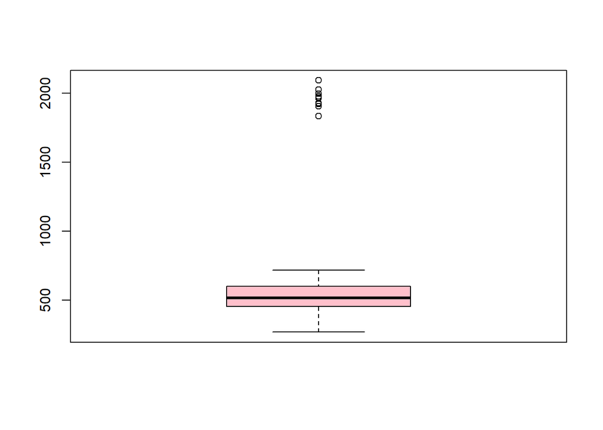

```r
boxplot(datos, col = "pink")
```

```r
# Calcular el primer y tercer cuartil (Q1 y Q3)
Q1 <- quantile(datos$Peso, 0.25)
Q3 <- quantile(datos$Peso, 0.75)

# Calcular el rango intercuartílico (IQR)
IQR <- Q3 - Q1

# Calcular los límites para los valores atípicos
limite_inferior <- Q1 - 1.5 * IQR
limite_superior <- Q3 + 1.5 * IQR

# Donde Q1 es el primer cuartil (25 percentil),
# Q3 el tercer cuartil (75 percentil),
# y IQR es el rango intercuartílico, definido como IQR  = Q3 - Q1
```

Estos límites son una forma de identificar valores que están significativamente por debajo o por encima del rango intercuartílico, que se considera una medida robusta de la dispersión de los datos. Los valores que caen fuera de estos límites se consideran valores atípicos potenciales.

Estos límites:

- Robustez: El método IQR es menos sensible a valores extremos en comparación con otras medidas de dispersión, como la desviación estándar, lo que lo hace más adecuado para datos con distribuciones sesgadas o con presencia de valores atípicos.
- Interpretación intuitiva: Los límites se definen en relación con la distribución de los datos, utilizando percentiles, lo que los hace fácilmente interpretables y aplicables a diferentes conjuntos de datos.
- Efectividad empírica: Aunque no existe un criterio universalmente aceptado para definir valores atípicos, el método IQR ha demostrado ser efectivo en la práctica para identificar valores extremos en una variedad de conjuntos de datos.

```r
# Identificar los valores atípicos
outliers <- datos$Peso[datos$Peso < limite_inferior | datos$Peso > limite_superior]
outliers
```

```
##  [1] 1928.959 2025.688 1975.331 1965.246 1904.838 1995.497 1921.510 1833.206
##  [9] 1961.977 2091.900
```

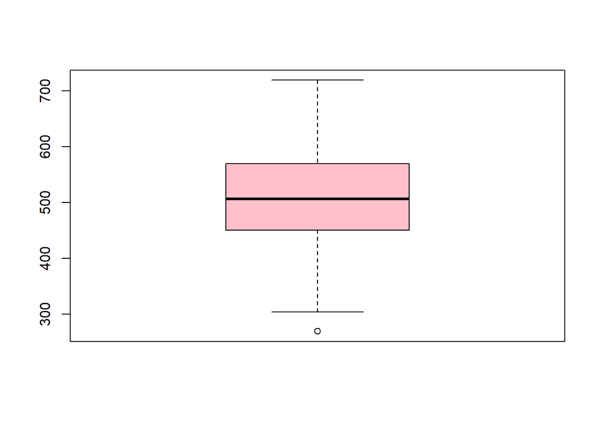

```r
# Eliminar los valores atípicos
datos_sin_outliers <- datos[!(datos$Peso < limite_inferior | datos$Peso > limite_superior), ]

boxplot(datos_sin_outliers, col = "pink")
```

¿Cúando es recomendable borrar los outliers?

- Errores de medición o entrada de datos: Si los valores atípicos son el resultado de errores en la medición o la entrada de datos, eliminarlos puede mejorar la precisión de los análisis.
- Violaciones de supuestos de los modelos: Si estás aplicando técnicas estadísticas que asumen normalidad o homocedasticidad de los datos y los outliers están afectando estos supuestos, eliminarlos puede mejorar la validez de los análisis.
- Análisis específicos: En algunos casos, los valores atípicos pueden distorsionar los resultados de ciertos análisis o modelos, como el cálculo de estadísticas descriptivas o la construcción de modelos predictivos. En tales situaciones, eliminarlos puede producir resultados más confiables.

Sin embargo, eliminar outliers también puede tener consecuencias negativas, como la pérdida de información o la introducción de sesgos en los análisis.